# Lab work 2 Poly

### Read the Data

### 1. Star JupyterLab and open the notebook named ex_11-1_fish that should be in this folder

```python
import pandas as pd
import seaborn as sns
fish = pd.read_csv('Fish.csv')
from sklearn.linear_model import LinearRegression
from sklearn.model_selection import train_test_split
```

### Section 1

```python
fish.info()
```

```
<class 'pandas.core.frame.DataFrame'>
RangeIndex: 159 entries, 0 to 158
Data columns (total 7 columns):
 #   Column   Non-Null Count  Dtype
---  ------   --------------  -----
 0   Species  159 non-null    object
 1   Weight   159 non-null    float64
 2   Length1  159 non-null    float64
 3   Length2  159 non-null    float64
 4   Length3  159 non-null    float64
 5   Height   159 non-null    float64
 6   Width    159 non-null    float64
dtypes: float64(6), object(1)
memory usage: 8.8+ KB
```

```python
fish.head()
```

|  | Species | Weight | Length1 | Length2 | Length3 | Height | Width |
| --- | --- | --- | --- | --- | --- | --- | --- |
| 0 | Bream | 242.0 | 23.2 | 25.4 | 30.0 | 11.5200 | 4.0200 |
| 1 | Bream | 290.0 | 24.0 | 26.3 | 31.2 | 12.4800 | 4.3056 |
| 2 | Bream | 340.0 | 23.9 | 26.5 | 31.1 | 12.3778 | 4.6961 |
| 3 | Bream | 363.0 | 26.3 | 29.0 | 33.5 | 12.7300 | 4.4555 |
| 4 | Bream | 430.0 | 26.5 | 29.0 | 34.0 | 12.4440 | 5.1340 |

### Clean Data

### 5. Rename the Length column to VerticalLength, Length2 to DiagonalLength, and Length3 to CrossLength.

```python
fish.rename(columns={'Length1':'VerticalLength',
                    'Length2':'DiagonalLength',
                    'Length3':'CrossLength'}, inplace=True)
```

### identify correclations

### 6.Use the corr() method to view how other columns correlate with the weight column

```python
fish1=fish.drop(columns=['Species'])
```

```python
fish1.corr()[['Weight']]
```

|  | Weight |
| --- | --- |
| Weight | 1.000000 |
| VerticalLength | 0.915712 |
| DiagonalLength | 0.918618 |
| CrossLength | 0.923044 |
| Height | 0.724345 |
| Width | 0.886507 |

### 7. Create a heatmap that shows how other columns correlate with the weight column

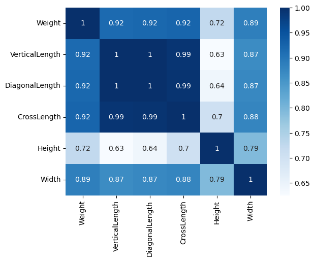

```python
sns.heatmap(data=fish1.corr(),annot=True, cmap='Blues')
```

### Create a multiple regression model

### 8.Use the correlation data choose three independent variables . The first two should be the Height and Width columns.The third should be one of the length columns.

```python
bream = fish.query('Species=="Bream"')
```

```python
x_train,x_test,y_train,y_test = train_test_split(
    bream[['Height', 'Width','VerticalLength']],
    bream[['Weight']])
```

```python
model= LinearRegression()
model.fit(x_train,y_train)
```

```
LinearRegression()
```

```python
model.score(x_test,y_test)
```

```
0.8825064953210423
```

```python
y_predicted = model.predict(x_test)
predicted =pd.DataFrame(y_predicted,columns=['PredictedWeight'])
```

```python
final=predicted.join([x_test.reset_index(drop=True),
                      y_test.reset_index(drop=True)])
```

### Plot the residuals

### 15.Caculate the residuals and store them in a new column in the DataFrame.

```python
final['Residual']=final.Weight-final.PredictedWeight
```

### 16.USe the kdeplot() method to create a KDE plot that plots the residuals.Note whether this provides a bell-shaped curve centered over 0.

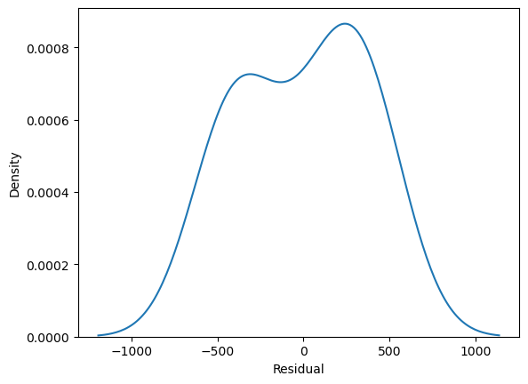

```python
sns.kdeplot(data=final,x='Residual')
```

### The medical Costs case study for section 3

### Create a simple regression to show the relatioship betweem charges amd age.

```python
import pandas as pd
import seaborn as sns
```

```python
df= pd.read_csv('insurance.csv')
```

```python
df.head()
```

|  | age | sex | bmi | children | smoker | region | charges |
| --- | --- | --- | --- | --- | --- | --- | --- |
| 0 | 19 | female | 27.900 | 0 | yes | southwest | 16884.92400 |
| 1 | 18 | male | 33.770 | 1 | no | southeast | 1725.55230 |
| 2 | 28 | male | 33.000 | 3 | no | southeast | 4449.46200 |
| 3 | 33 | male | 22.705 | 0 | no | northwest | 21984.47061 |
| 4 | 32 | male | 28.880 | 0 | no | northwest | 3866.85520 |

```python
df.info()
```

```
<class 'pandas.core.frame.DataFrame'>
RangeIndex: 1338 entries, 0 to 1337
Data columns (total 7 columns):
 #   Column    Non-Null Count  Dtype
---  ------    --------------  -----
 0   age       1338 non-null   int64
 1   sex       1338 non-null   object
 2   bmi       1338 non-null   float64
 3   children  1338 non-null   int64
 4   smoker    1338 non-null   object
 5   region    1338 non-null   object
 6   charges   1338 non-null   float64
dtypes: float64(2), int64(2), object(3)
memory usage: 73.3+ KB
```

### How is age related to medical costs?

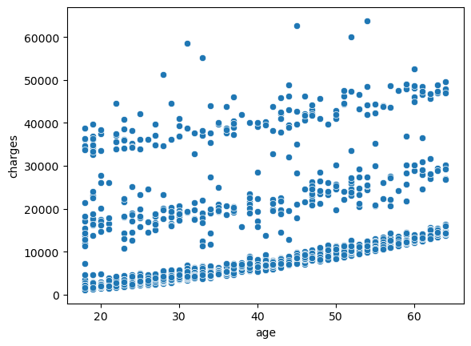

```python
sns.scatterplot(data=df,x='age',y='charges')
```

### How is number of children related to medical costs?

```python
children = df.groupby('children').mean()[['charges']].reset_index()
children
```

|  | children | charges |
| --- | --- | --- |
| 0 | 0 | 12365.975602 |
| 1 | 1 | 12731.171832 |
| 2 | 2 | 15073.563734 |
| 3 | 3 | 15355.318367 |
| 4 | 4 | 13850.656311 |
| 5 | 5 | 8786.035247 |

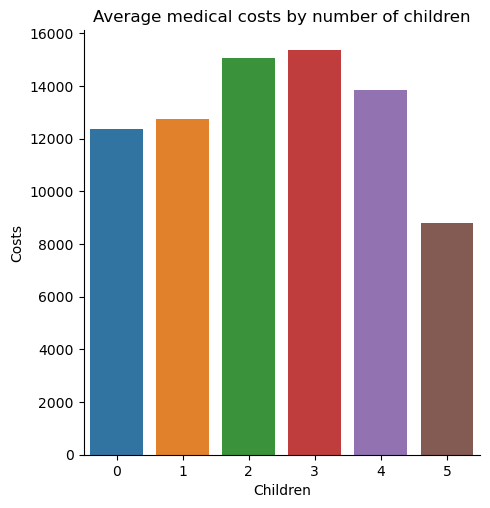

```python
g = sns.catplot(data = children, kind='bar',x='children', y = 'charges')

for ax in g.axes.flat:
    ax.set(title='Average medical costs by number of children',
          ylabel='Costs',
          xlabel='Children')
```

### The Plot above shows how to cost relate to the number of children

A person's medical costs go up with the number of chidren will you reach 3 children.After that, they go down. This might be due to the small sample size for people that more than 3 children as shown by the table below

```python
df.groupby('children').count()[['age']]
```

| children | age |
| --- | --- |
| 0 | 574 |
| 1 | 324 |
| 2 | 240 |
| 3 | 157 |
| 4 | 25 |
| 5 | 18 |

### How is the number of people distributed by region?

```python
df.groupby('region').count()[['charges']]
```

| region | charges |
| --- | --- |
| northeast | 324 |
| northwest | 325 |
| southeast | 364 |
| southwest | 325 |

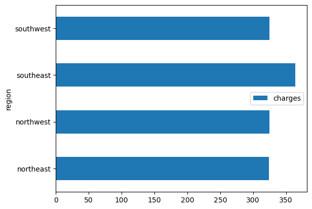

```python
df.groupby('region').count()[['charges']].plot(kind='barh')
```

#### The number of people sampled from each region is roughty eaqual,but there is slightly more in the southeast

### How is the number of people distributed by age?

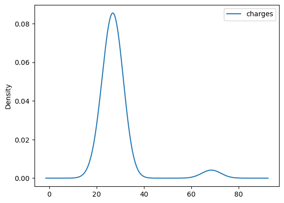

```python
df.groupby('age').count()[['charges']].plot(kind='kde')
```

### How are charges distributed?

```python
df.charges.describe()
```

```
count     1338.000000
mean     13270.422265
std      12110.011237
min       1121.873900
25%       4740.287150
50%       9382.033000
75%      16639.912515
max      63770.428010
Name: charges, dtype: float64
```

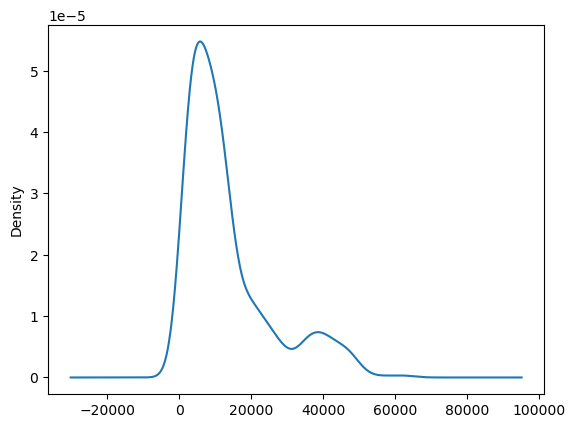

```python
df.charges.plot(kind='kde')
```

#### Most charge are less than 20.000 but the charges range up to about 63,000

## Bin the bmi data

classification for bmi: <18.5 = underweight 18.6-24.9=healthy 25-29.9=overweight 30+=obese

```python
df['bmiBinned']=pd.cut(df.bmi,bins=[0,18.5,25.0,30.0,100],
                       labels=['Underweight','Healthy','Overweight','Obese'],
                        right=True)
df.head()
```

|  | age | sex | bmi | children | smoker | region | charges | bmiBinned |
| --- | --- | --- | --- | --- | --- | --- | --- | --- |
| 0 | 19 | female | 27.900 | 0 | yes | southwest | 16884.92400 | Overweight |
| 1 | 18 | male | 33.770 | 1 | no | southeast | 1725.55230 | Obese |
| 2 | 28 | male | 33.000 | 3 | no | southeast | 4449.46200 | Obese |
| 3 | 33 | male | 22.705 | 0 | no | northwest | 21984.47061 | Healthy |
| 4 | 32 | male | 28.880 | 0 | no | northwest | 3866.85520 | Overweight |

### How are the charges related to the bmi

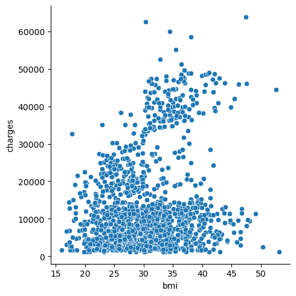

```python
sns.relplot(data=df,x='bmi',y='charges',kind='scatter')
```

#### The scatter plot above shows that medical charges increase as bmi increase

### How is the smoker status related to the charges?

```python
df.groupby('smoker').describe()[['charges']].T
```

|  | smoker | no | yes |
| --- | --- | --- | --- |
| charges | count | 1064.000000 | 274.000000 |
|  | mean | 8434.268298 | 32050.231832 |
|  | std | 5993.781819 | 11541.547176 |
|  | min | 1121.873900 | 12829.455100 |
|  | 25% | 3986.438700 | 20826.244213 |
|  | 50% | 7345.405300 | 34456.348450 |
|  | 75% | 11362.887050 | 41019.207275 |
|  | max | 36910.608030 | 63770.428010 |

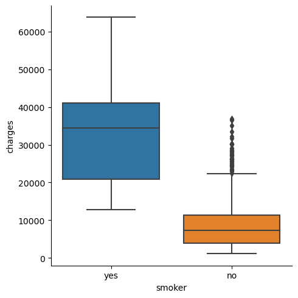

```python
sns.catplot(data=df,x='smoker',y='charges',kind='box')
```

since the mean can be skedwed by outlies, its best to use the describe()method so that you can examine the data ar several percentiles to get a more definitive picture of the data.As you can see, from the min to the max , the medical charges are far higher for smokers.

#### Smokers' medical bills are much higher than non-smokers

### How are the charges related to the region?

```python
df.groupby('region').describe()[['charges']].T
```

|  | region | northeast | northwest | southeast | southwest |
| --- | --- | --- | --- | --- | --- |
| charges | count | 324.000000 | 325.000000 | 364.000000 | 325.000000 |
|  | mean | 13406.384516 | 12417.575374 | 14735.411438 | 12346.937377 |
|  | std | 11255.803066 | 11072.276928 | 13971.098589 | 11557.179101 |
|  | min | 1694.796400 | 1621.340200 | 1121.873900 | 1241.565000 |
|  | 25% | 5194.322288 | 4719.736550 | 4440.886200 | 4751.070000 |
|  | 50% | 10057.652025 | 8965.795750 | 9294.131950 | 8798.593000 |
|  | 75% | 16687.364100 | 14711.743800 | 19526.286900 | 13462.520000 |
|  | max | 58571.074480 | 60021.398970 | 63770.428010 | 52590.829390 |

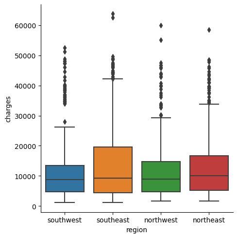

```python
sns.catplot(data=df,x='region',y='charges',kind='box')
```

### The southeast has more charges on the higher end

### Which region has the highest obesity percentage?

```python
pctByRegion=df.groupby('region')['bmiBinned'].value_counts(normalize=True).to_frame()
pctByRegion.columns= ['percent']
pctByRegion.reset_index(inplace=True)
pctByRegion
```

|  | region | bmiBinned | percent |
| --- | --- | --- | --- |
| 0 | northeast | Obese | 0.441358 |
| 1 | northeast | Overweight | 0.302469 |
| 2 | northeast | Healthy | 0.225309 |
| 3 | northeast | Underweight | 0.030864 |
| 4 | northwest | Obese | 0.455385 |
| 5 | northwest | Overweight | 0.329231 |
| 6 | northwest | Healthy | 0.193846 |
| 7 | northwest | Underweight | 0.021538 |
| 8 | southeast | Obese | 0.667582 |
| 9 | southeast | Overweight | 0.219780 |
| 10 | southeast | Healthy | 0.112637 |
| 11 | southeast | Underweight | 0.000000 |
| 12 | southwest | Obese | 0.526154 |
| 13 | southwest | Overweight | 0.310769 |
| 14 | southwest | Healthy | 0.150769 |
| 15 | southwest | Underweight | 0.012308 |

### Section 3

```python
from sklearn.model_selection import train_test_split
from sklearn.linear_model import LinearRegression
from sklearn.preprocessing import StandardScaler
from sklearn.feature_selection import mutual_info_regression
from sklearn.feature_selection import f_regression
from sklearn.feature_selection import SelectKBest
```

### Create a simple regression to show the relationship between charges and age.

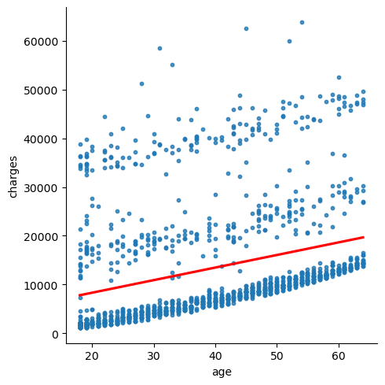

```python
sns.lmplot(data=df,x='age', y='charges',ci=None,
         line_kws={'color':'red'},scatter_kws={'s':10})
```

### How does this relationship change withs smoking status?

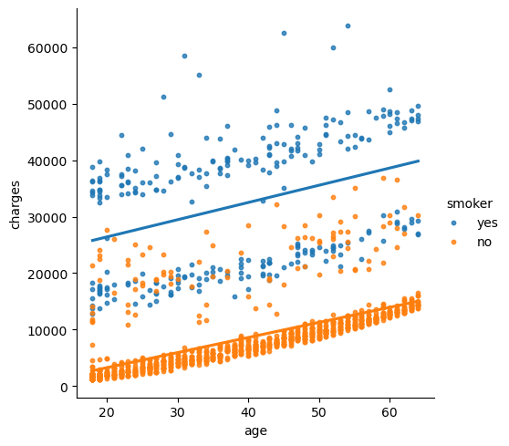

```python
sns.lmplot(data=df,x='age', y='charges',hue='smoker',
       ci=None,scatter_kws={'s':10})
```

### Charges start higher for smokers

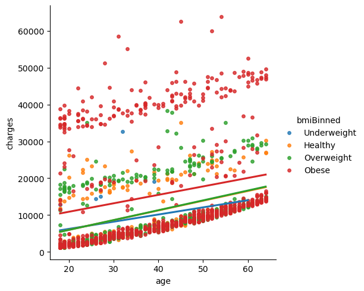

```python
sns.lmplot(data=df,x='age', y='charges',hue='bmiBinned',
       ci=None,scatter_kws={'s':15})
```

#### Most of highest charges are for people that are either overweight or obese

### Create a multiple regression to predict the charges

```python
df.children=df.children.astype(str)
```

```python
catCols = ['sex','children','smoker','region','bmiBinned']
dummies= pd.get_dummies(df[catCols])
dfDummies=df.drop(columns=catCols)
dfDummies=dfDummies.join(dummies)
```

```python
dfDummies
```

|  | age | bmi | charges | sex_female | sex_male | children_0 | children_1 | children_2 | children_3 | children_4 | ... | smoker_no | smoker_yes | region_northeast | region_northwest | region_southeast | region_southwest | bmiBinned_Underweight | bmiBinned_Healthy | bmiBinned_Overweight | bmiBinned_Obese |
| --- | --- | --- | --- | --- | --- | --- | --- | --- | --- | --- | --- | --- | --- | --- | --- | --- | --- | --- | --- | --- | --- |
| 0 | 19 | 27.900 | 16884.92400 | 1 | 0 | 1 | 0 | 0 | 0 | 0 | ... | 0 | 1 | 0 | 0 | 0 | 1 | 0 | 0 | 1 | 0 |
| 1 | 18 | 33.770 | 1725.55230 | 0 | 1 | 0 | 1 | 0 | 0 | 0 | ... | 1 | 0 | 0 | 0 | 1 | 0 | 0 | 0 | 0 | 1 |
| 2 | 28 | 33.000 | 4449.46200 | 0 | 1 | 0 | 0 | 0 | 1 | 0 | ... | 1 | 0 | 0 | 0 | 1 | 0 | 0 | 0 | 0 | 1 |
| 3 | 33 | 22.705 | 21984.47061 | 0 | 1 | 1 | 0 | 0 | 0 | 0 | ... | 1 | 0 | 0 | 1 | 0 | 0 | 0 | 1 | 0 | 0 |
| 4 | 32 | 28.880 | 3866.85520 | 0 | 1 | 1 | 0 | 0 | 0 | 0 | ... | 1 | 0 | 0 | 1 | 0 | 0 | 0 | 0 | 1 | 0 |
| ... | ... | ... | ... | ... | ... | ... | ... | ... | ... | ... | ... | ... | ... | ... | ... | ... | ... | ... | ... | ... | ... |
| 1333 | 50 | 30.970 | 10600.54830 | 0 | 1 | 0 | 0 | 0 | 1 | 0 | ... | 1 | 0 | 0 | 1 | 0 | 0 | 0 | 0 | 0 | 1 |
| 1334 | 18 | 31.920 | 2205.98080 | 1 | 0 | 1 | 0 | 0 | 0 | 0 | ... | 1 | 0 | 1 | 0 | 0 | 0 | 0 | 0 | 0 | 1 |
| 1335 | 18 | 36.850 | 1629.83350 | 1 | 0 | 1 | 0 | 0 | 0 | 0 | ... | 1 | 0 | 0 | 0 | 1 | 0 | 0 | 0 | 0 | 1 |
| 1336 | 21 | 25.800 | 2007.94500 | 1 | 0 | 1 | 0 | 0 | 0 | 0 | ... | 1 | 0 | 0 | 0 | 0 | 1 | 0 | 0 | 1 | 0 |
| 1337 | 61 | 29.070 | 29141.36030 | 1 | 0 | 1 | 0 | 0 | 0 | 0 | ... | 0 | 1 | 0 | 1 | 0 | 0 | 0 | 0 | 1 | 0 |

1338 rows × 21 columns

```python
scaler= StandardScaler()
numCols= ['bmi','age']
dfDummies[numCols]=scaler.fit_transform(dfDummies[numCols])
dfDummies.head()
```

[output not shown]

```python
dfDummies.corr()[['charges']].sort_values('charges',ascending=False)
```

|  | charges |
| --- | --- |
| charges | 1.000000 |
| smoker_yes | 0.787251 |
| age | 0.299008 |
| bmiBinned_Obese | 0.199683 |
| bmi | 0.198341 |
| region_southeast | 0.073982 |
| children_2 | 0.069639 |
| children_3 | 0.062795 |
| sex_male | 0.057292 |
| children_4 | 0.006614 |
| region_northeast | 0.006349 |
| children_1 | -0.025180 |
| region_northwest | -0.039905 |
| region_southwest | -0.043210 |
| children_5 | -0.043258 |
| bmiBinned_Underweight | -0.048117 |
| sex_female | -0.057292 |
| children_0 | -0.064760 |
| bmiBinned_Healthy | -0.105577 |
| bmiBinned_Overweight | -0.119542 |
| smoker_no | -0.787251 |

```python
dfTrain,dfTest= train_test_split(dfDummies,test_size=0.2,random_state=20)
```

```python
model= LinearRegression()
xCols= ['smoker_yes','age','bmi']
```

```python
model.fit(dfTrain[xCols],dfTrain['charges'])
model.score(dfTest[xCols],dfTest['charges'])
```

```
0.7963444799919928
```

### Make Predictions with the multiple regression model

```python
y_pred=model.predict(dfTest[xCols])
```

```python
predictions=dfTest[['charges']].reset_index(drop=True).join(pd.Series(y_pred,name='predicted'))
```

```python
predictions['residuals']=predictions.charges-predictions.predicted
```

## at 3.36s on video

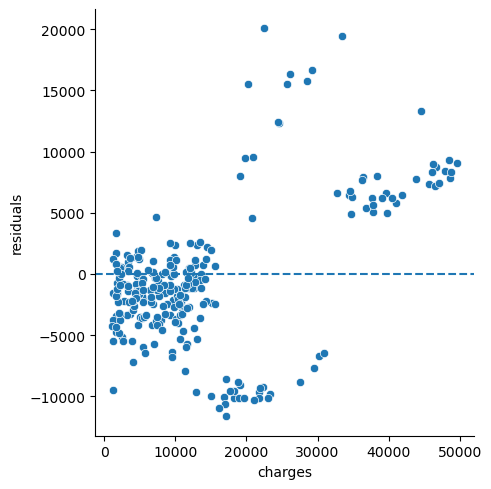

```python
g=sns.relplot(data=predictions,x='charges',y='residuals',kind='scatter')
for ax in g.axes.flat:
    ax.axhline(0,ls='--')
```

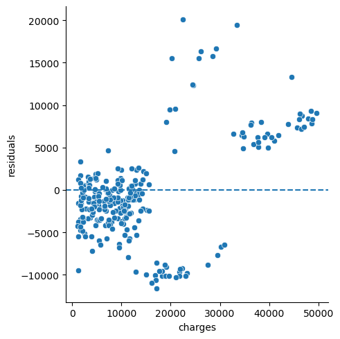

```python
g = sns.relplot(data=predictions, x='charges', y='residuals', kind='scatter')
for ax in g.axes.flat:
    ax.axhline(0, ls='--')
```

### the model is more accurate for the lower charger, but its perfomance gets worse at the charges get higher

## What is the optimal number of parameters for the multiple regression model?

```python
fs= SelectKBest(score_func=mutual_info_regression, k='all')
fs.fit(dfTrain.drop(columns=['charges']),dfTrain['charges'])

x_train_fs=fs.transform(dfTrain.drop(columns=['charges']))
x_test_df=fs.transform(dfTrain.drop(columns=['charges']))
```

```python
model= LinearRegression()
testScores=[]
trainScores=[]
for i in range(1,len(dfTrain.columns)):
    fs= SelectKBest(score_func=mutual_info_regression, k=i)
    fs.fit(dfTrain.drop(columns=['charges']),dfTrain['charges'])
    x_test_fs=fs.transform(dfTest.drop(columns=['charges']))
    x_train_fs=fs.transform(dfTrain.drop(columns=['charges']))

    model.fit(x_train_fs,dfTrain['charges'])

    testScore =model.score(x_test_fs,dfTest['charges'])
    trainScore =model.score(x_train_fs,dfTrain['charges'])
    testScores.append(testScore)
    trainScores.append(trainScore)
```

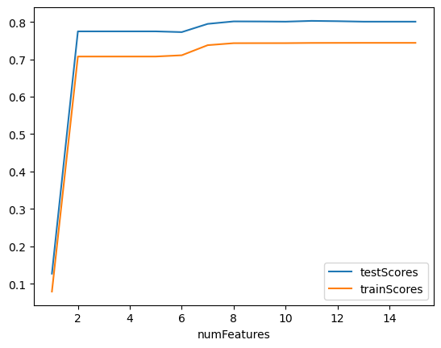

```python
features=pd.DataFrame(data={'testScores':testScores,'trainScores':trainScores})
features.reset_index(inplace=True)
features.rename(columns={'index':'numFeatures'},inplace=True)
features.numFeatures=features.numFeatures+1
features.plot(x='numFeatures',y=['testScores','trainScores'])
```